| title: ‘Relatorio de apoio a campanhas futuras para o Marketing’ |
| --- |
| author: “André Christian F G Almeida” |
| date: “2024-08-20” |
| output: |
| html_document: default |

Nesta reunião, foi apresentado a Cyclistic, uma empresa de mobilidade com foco na sustentabilidade e compartilhamento de bicicletas de diversos tipos como: reclináveis, triciclos manuais e de carga. Hoje, ela conta com mais de 5.800 unidades e cerca de 692 estações de compartilhamento em Chicago.

## Identificação da tarefa de negócios, desafios e principais stakeholders.

Hoje a Cyclistic tem um desafio: Aumentar a taxa de conversão de clientes casuais (aqueles que assinam os planos diários e mensais) em membros Cyclistic (aqueles que assinam planos anuais). Através dos dados podemos realizar análises exploratórias e descritivas para descobrir o padrão de utilização dos membros, como: horas utilizadas, trajeto efetuado, quantidade de uso em determinado período etc.

**Principais tarefas**

- Baixar os dados de utilização de todos os clientes dos últimos 12 meses
- Realizar a estruturação dos dados
- Realizar a limpeza dos dados
- Realizar a análise exploratória dos dados
- Realizar a análise descritiva dos dados
- Criar as visualizações das **três principais** recomendações com base na análise
- Apresentar para os stakeholders

**Stakeholders e seu objetivo**

A Lily Moreno, diretora de Marketing e responsável pelas campanhas de e-mail, mídias e outros canais juntamente com a sua equipe de marketing desejam descobrir tendências através dos dados históricos.

**Conclusão**

Ao analisar os dados fornecidos e gerar insights, podemos auxiliar o setor de Marketing a criar campanhas estratégicas, a fim de converter os clientes casuais em membros Cyclistic respondendo as seguintes perguntas:

1. Como os membros Cyclistic e ciclistas casuais usam as bicicletas da Cyclistic de forma diferente?
2. Por que os ciclistas casuais iriam querer adquirir planos planos anuais da Cyclistic?
3. Como a Cyclistic pode usar a mídia digital para influenciar os passageiros casuais a se tornarem membros cyclistic?

```
✅ Com esta entrega, finalizamos a primeira etapa de um processo de análise de dados: Perguntar
```

### Preparação e Armazenamento dos Dados

Os dados foram fornecidos através de um [link](https://divvy-tripdata.s3.amazonaws.com/index.html) sob uma [licença](https://www.divvybikes.com/data-license-agreement) pela Divvy, empresa operada pela Motivate International Inc., uma entidade reconhecida e respeitada no setor de compartilhamento de bicicletas.

Coletados de forma automática pelos sistema de compartilhamento, os dados sugerem uma coleta consistente e precisa, no entanto, foram identificados valores nulos, que serão tratados e validados.

Levando em consideração os pontos cruciais citados, como: Precisão, Atualidade, Objetividade, Viés, Integridade e Licenciamento, podemos garantir que os dados utilizados serão confiáveis e apropriados para análise. Fortalecendo a confiabilidade as conclusões tiradas.

**Etapas de processamento** - Download dos arquivos - Extração de cada um das respectivas pastas zips - Junção dos arquivos csv’s extraídos na pasta “ProjetoAnaliseCyclistic” - Criar o dataframe com todos os arquivos

```r
# Definição do diretório dos arquivos
diretorio <- "C:/Users/André/Documents/ProjetoBike/ProjetoAnaliseCyclistic"
```

```r
# Leitura de cada arquivo csv
arquivos <- list.files(diretorio, pattern = "*.csv", full.names = TRUE)
```

```r
# Listagem dos arquivos existentes na pasta
  leitura_arq <- function(file){
  read.csv(file)
  }
```

```r
# Criação do dataframe com os arquivos existentes
 df_historico <- map_df(arquivos, leitura_arq)
```

```r
# Visualização das variáveis e seus tipos
str(df_historico)
```

```
## 'data.frame':    7058826 obs. of  13 variables:
##  $ ride_id           : chr  "0D9FA920C3062031" "92485E5FB5888ACD" "FB144B3FC8300187" "DDEB93BC2CE9AA77" ...
##  $ rideable_type     : chr  "electric_bike" "electric_bike" "electric_bike" "classic_bike" ...
##  $ started_at        : chr  "2023-05-07 19:53:48" "2023-05-06 18:54:08" "2023-05-21 00:40:21" "2023-05-10 16:47:01" ...
##  $ ended_at          : chr  "2023-05-07 19:58:32" "2023-05-06 19:03:35" "2023-05-21 00:44:36" "2023-05-10 16:59:52" ...
##  $ start_station_name: chr  "Southport Ave & Belmont Ave" "Southport Ave & Belmont Ave" "Halsted St & 21st St" "Carpenter St & Huron St" ...
##  $ start_station_id  : chr  "13229" "13229" "13162" "13196" ...
##  $ end_station_name  : chr  "" "" "" "Damen Ave & Cortland St" ...
##  $ end_station_id    : chr  "" "" "" "13133" ...
##  $ start_lat         : num  41.9 41.9 41.9 41.9 42 ...
##  $ start_lng         : num  -87.7 -87.7 -87.6 -87.7 -87.7 ...
##  $ end_lat           : num  41.9 41.9 41.9 41.9 41.9 ...
##  $ end_lng           : num  -87.7 -87.7 -87.7 -87.7 -87.7 ...
##  $ member_casual     : chr  "member" "member" "member" "member" ...
```

```
✅ Com esta entrega, finalizamos a segunda etapa de um processo de análise de dados: Preparar para exploração
```

### Processamento dos dados

Para esta etapa temos que: * Verificar se há valores nulos * Verificar se há valores duplicados * Conversão das colunas started_at e ended_at de texto para data * Criaçao das coluna duration_trip, que mostra a duração de cada viagem * Criação da coluna day_of_the_week, que mostra que dia da semana cada viagem começou

```r
# Sumário estátistico do data frame
df_summary <- dfSummary(df_historico)
  print(df_summary)
```

```
## Data Frame Summary
## df_historico
## Dimensions: 7058826 x 13
## Duplicates: 0
##
## ----------------------------------------------------------------------------------------------------------------------------
## No   Variable             Stats / Values                 Freqs (% of Valid)       Graph                 Valid      Missing
## ---- -------------------- ------------------------------ ------------------------ --------------------- ---------- ---------
## 1    ride_id              1. 011C8EF97AB0F30D                  2 (  0.0%)                               7058826    0
##      [character]          2. 01406457A85B0AFF                  2 (  0.0%)                               (100.0%)   (0.0%)
##                           3. 02606FBC7F8537EE                  2 (  0.0%)
##                           4. 0354FD0756337B59                  2 (  0.0%)
##                           5. 048C715F1DE0D8C0                  2 (  0.0%)
##                           6. 05D27072A33A290C                  2 (  0.0%)
##                           7. 0625A51D397A68F9                  2 (  0.0%)
##                           8. 076F662AFB9CAEC1                  2 (  0.0%)
##                           9. 07DBFDA3C91006AE                  2 (  0.0%)
##                           10. 0AE60485F97A473D                 2 (  0.0%)
##                           [ 7058605 others ]             7058806 (100.0%)         IIIIIIIIIIIIIIIIIII
##
## 2    rideable_type        1. classic_bike                3437335 (48.7%)          IIIIIIIII             7058826    0
##      [character]          2. docked_bike                   62447 ( 0.9%)                                (100.0%)   (0.0%)
##                           3. electric_bike               3559044 (50.4%)          IIIIIIIIII
##
## 3    started_at           1. 2023-07-13 17:38:08               8 (  0.0%)                               7058826    0
##      [character]          2. 2023-05-10 17:20:41               7 (  0.0%)                               (100.0%)   (0.0%)
##                           3. 2023-05-16 17:20:12               7 (  0.0%)
##                           4. 2023-05-19 16:18:05               7 (  0.0%)
##                           5. 2023-05-21 13:32:30               7 (  0.0%)
##                           6. 2023-06-02 16:36:57               7 (  0.0%)
##                           7. 2023-06-07 18:19:47               7 (  0.0%)
##                           8. 2023-06-17 11:36:31               7 (  0.0%)
##                           9. 2023-06-23 17:51:51               7 (  0.0%)
##                           10. 2023-06-30 15:49:32              7 (  0.0%)
##                           [ 6055515 others ]             7058755 (100.0%)         IIIIIIIIIIIIIIIIIII
##
## 4    ended_at             1. 2023-12-08 09:54:28              18 (  0.0%)                               7058826    0
##      [character]          2. 2023-08-03 07:16:39              15 (  0.0%)                               (100.0%)   (0.0%)
##                           3. 2023-09-14 17:09:23              14 (  0.0%)
##                           4. 2024-06-08 12:51:04.436          14 (  0.0%)
```

[output cut: 68 more lines]

```
## 11   end_lat              Mean (sd) : 41.9 (0.1)         14124 distinct values                      :   7049308    9518
##      [numeric]            min < med < max:                                                          :   (99.9%)    (0.1%)
##                           0 < 41.9 < 42.2                                                           :
##                           IQR (CV) : 0.1 (0)                                                        :
##                                                                                                     :
##
## 12   end_lng              Mean (sd) : -87.6 (0.1)        14243 distinct values    :                     7049308    9518
##      [numeric]            min < med < max:                                        :                     (99.9%)    (0.1%)
##                           -88.2 < -87.6 < 0                                       :
##                           IQR (CV) : 0 (0)                                        :
##                                                                                   :
##
## 13   member_casual        1. casual                      2584797 (36.6%)          IIIIIII               7058826    0
##      [character]          2. member                      4474029 (63.4%)          IIIIIIIIIIII          (100.0%)   (0.0%)
## ----------------------------------------------------------------------------------------------------------------------------
```

```r
# Remove as linhas duplicadas com base na coluna ride_id
  df_historico_limpo <- df_historico %>%
    distinct(ride_id, .keep_all = TRUE)
```

```r
# Verificação se ainda há linhas duplicadas
existe_duplicadas <- df_historico_limpo %>%
  filter(duplicated(ride_id) | duplicated(ride_id, fromLast = TRUE)) %>%
  nrow() > 0
print(existe_duplicadas)
```

```
## [1] FALSE
```

```r
# Verificação se há pelo menos um valor nulo ou vazio em cada linha
verifica_vazio_ou_nulo <- function(x) {
  if (is.character(x)) {
    return(is.na(x) | x == "")
  } else {
    return(is.na(x))
  }
}
```

```r
# Aplicar a função para cada linha do dataframe
linha_com_problemas <- apply(df_historico_limpo, 1, function(row) any(verifica_vazio_ou_nulo(row)))
```

```r
# Filtrar o dataframe para remover as linhas com erros e manter o dataframe original
df_historico_limpo <- df_historico_limpo[!linha_com_problemas, ]
```

```r
# Exibição da quantidade de linhas antes e depois da limpeza
numero_de_linhas_antes <- nrow(df_historico)
 numero_de_linhas_depois <- nrow(df_historico_limpo)

  print(paste("Número de linhas antes da limpeza: ", numero_de_linhas_antes))
```

```
## [1] "Número de linhas antes da limpeza:  7058826"
```

```r
  print(paste("Número de linhas depois da limpeza: ", numero_de_linhas_depois))
```

```
## [1] "Número de linhas depois da limpeza:  5272212"
```

```r
# Adissão da coluna "duration_trip" ao dataframe
# conversão da colunas started_at e ended_at para "difftime"
  df_historico_limpo$started_at <- ymd_hms(df_historico_limpo$started_at)
  df_historico_limpo$ended_at <- ymd_hms(df_historico_limpo$ended_at)
# Calculo da duração e conversão para minutos arrendondados para cima
  df_historico_limpo <- df_historico_limpo %>%
    mutate(duration_trip = ceiling(difftime(ended_at, started_at, units = "mins"))) #em minutos
```

```r
# Criação da coluna day_of_the_week
 df_historico_limpo <- df_historico_limpo %>%
    mutate(day_of_the_week = wday(started_at, label = TRUE))
```

```
✅ Com esta entrega, finalizamos a terceira etapa de um processo de análise de dados: Processar
```

### Análise Exploratória e Descritiva do Dataframe

```r
# Criação de um novo sumário com os dados limpos
df_summary <- dfSummary(df_historico_limpo)
  print(df_summary)
```

```
## Data Frame Summary
## df_historico_limpo
## Dimensions: 5272212 x 15
## Duplicates: 0
##
## --------------------------------------------------------------------------------------------------------------------------------
## No   Variable             Stats / Values                    Freqs (% of Valid)        Graph                 Valid      Missing
## ---- -------------------- --------------------------------- ------------------------- --------------------- ---------- ---------
## 1    ride_id              1. 00000065B3150FF2                     1 (  0.0%)                                5272212    0
##      [character]          2. 0000089D36728778                     1 (  0.0%)                                (100.0%)   (0.0%)
##                           3. 0000140539E54BF2                     1 (  0.0%)
##                           4. 000018486CBEF63A                     1 (  0.0%)
##                           5. 000019B6351D28DF                     1 (  0.0%)
##                           6. 00001F1414872B6A                     1 (  0.0%)
##                           7. 000023AB39488896                     1 (  0.0%)
##                           8. 00002447D8785F1C                     1 (  0.0%)
##                           9. 000028BC6D9349BE                     1 (  0.0%)
##                           10. 00002E1E858F6AB7                    1 (  0.0%)
##                           [ 5272202 others ]                5272202 (100.0%)          IIIIIIIIIIIIIIIIIII
##
## 2    rideable_type        1. classic_bike                   3429041 (65.0%)           IIIIIIIIIIIII         5272212    0
##      [character]          2. docked_bike                      60687 ( 1.2%)                                 (100.0%)   (0.0%)
##                           3. electric_bike                  1782484 (33.8%)           IIIIII
##
## 3    started_at           min : 2023-05-01 00:00:33         4673083 distinct values     . :             .   5272212    0
##      [POSIXct, POSIXt]    med : 2023-09-29 17:04:20.5                                 : : : :           :   (100.0%)   (0.0%)
##                           max : 2024-06-30 23:54:52.215                               : : : : .       : :
##                           range : 1y 1m 29d 23H 54M 19.2S                             : : : : : . . : : :
##                                                                                       : : : : : : : : : :
##
## 4    ended_at             min : 2023-05-01 00:04:28         4684973 distinct values     . :             .   5272212    0
##      [POSIXct, POSIXt]    med : 2023-09-29 17:20:45.5                                 : : : :           :   (100.0%)   (0.0%)
##                           max : 2024-06-30 23:59:57.93                                : : : : .       : :
##                           range : 1y 1m 29d 23H 55M 29.9S                             : : : : : .   : : :
##                                                                                       : : : : : : : : : :
##
## 5    start_station_name   1. Streeter Dr & Grand Ave          76893 ( 1.5%)                                 5272212    0
##      [character]          2. DuSable Lake Shore Dr & M        51031 ( 1.0%)                                 (100.0%)   (0.0%)
##                           3. Michigan Ave & Oak St            45174 ( 0.9%)
##                           4. DuSable Lake Shore Dr & N        44538 ( 0.8%)
```

[output cut: 70 more lines]

```
##
## 14   duration_trip        min : -54                         1516 distinct values      :                     5272212    0
##      [difftime]           med : 11                                                    :                     (100.0%)   (0.0%)
##                           max : 12137                                                 :
##                           units : mins                                                :
##                                                                                       :
##
## 15   day_of_the_week      1. dom                            708832 (13.4%)            II                    5272212    0
##      [ordered, factor]    2. seg                            696114 (13.2%)            II                    (100.0%)   (0.0%)
##                           3. ter                            747136 (14.2%)            II
##                           4. qua                            772903 (14.7%)            II
##                           5. qui                            775433 (14.7%)            II
##                           6. sex                            751385 (14.3%)            II
##                           7. sáb                            820409 (15.6%)            III
## --------------------------------------------------------------------------------------------------------------------------------
```

#### Análise exploratória

```
💡 O tipo de bicicleta com menor frequência de uso são as docked_bike (bicicletas cargueiras), com 1.2% dos registros e as classic_bike(bicicletas comuns) dominam, com 65.0% dos registros
```

```
💡 De 5272212 registros, 36% são de membros casuais e 64% de membros Cyclistic
```

[output not shown]

```r
# 💡 O dia em que os clientes mais utilizam o serviço é no sábado
freq_day_of_the_week <- table(df_historico_limpo$day_of_the_week)
moda <- names(freq_day_of_the_week)[which.max(freq_day_of_the_week)]
moda
```

```
## [1] "sáb"
```

```r
# 💡 O tipo de bicicleta que mais utilizam são as bicicletas normais
freq_rideable_type <- table(df_historico_limpo$rideable_type)
moda <- names(freq_rideable_type[which.max(freq_rideable_type)])
moda
```

```
## [1] "classic_bike"
```

#### Análise exploratória

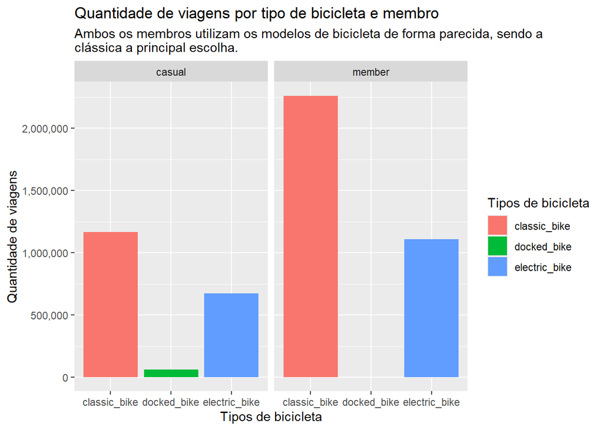

```r
title_text <- str_wrap("Quantidade de viagens por tipo de bicicleta e membro")
subtitle_text <- str_wrap("Ambos os membros utilizam os modelos de bicicleta de forma parecida, sendo a clássica a principal escolha.")
  ggplot(data = df_historico_limpo) +
    geom_bar(mapping = aes(x = rideable_type, fill = rideable_type)) +
    facet_wrap(~member_casual) +
    labs(title = title_text,
       subtitle = subtitle_text,
       y = "Quantidade de viagens",
       x = "Tipos de bicicleta",
       fill = "Tipos de bicicleta") +
   scale_y_continuous(labels = scales::comma_format()) # separação de milhares
```

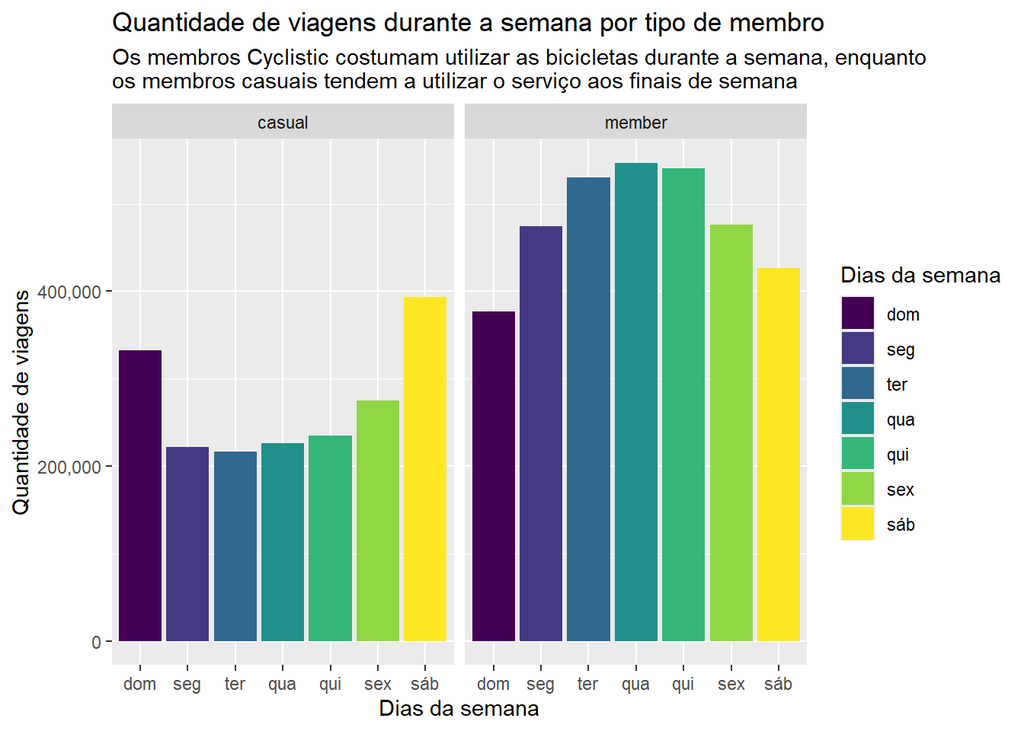

```r
title_text <- str_wrap("Quantidade de viagens durante a semana por tipo de membro")
subtitle_text <- str_wrap("Os membros Cyclistic costumam utilizar as bicicletas durante a semana, enquanto os membros casuais tendem a utilizar o serviço aos finais de semana")
  ggplot(data = df_historico_limpo) +
  geom_bar(mapping = aes(x = day_of_the_week, fill = day_of_the_week)) +
  facet_wrap(~member_casual) +
  labs(title = title_text,
       subtitle = subtitle_text,
       y = "Quantidade de viagens",
       x = "Dias da semana",
       fill = "Dias da semana") +
  scale_y_continuous(labels = scales::comma_format()) # separação de milhares
```

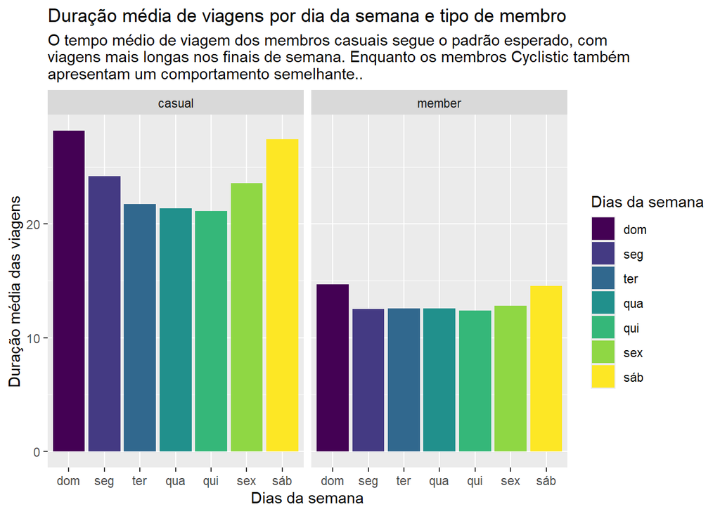

```r
title_text <- str_wrap("Duração média de viagens por dia da semana e tipo de membro")
    subtitle_text <- str_wrap("O tempo médio de viagem dos membros casuais segue o padrão esperado, com viagens mais longas nos finais de semana. Enquanto os membros Cyclistic também apresentam um comportamento semelhante..")
df_historico_limpo %>%
 mutate(duration_trip_min = as.numeric(duration_trip, units = "mins")) %>%
 group_by(day_of_the_week, member_casual) %>%
    summarize(mean_duration_trip = mean(duration_trip_min), .groups = 'drop') %>%
    ggplot(aes(x = day_of_the_week, y = mean_duration_trip, fill = day_of_the_week)) +
    geom_bar(stat = "identity") +
    facet_wrap(~member_casual) +
labs(title = title_text,
     subtitle = subtitle_text,
     y = "Duração média das viagens",
     x = "Dias da semana",
     fill = "Dias da semana")
```

### Resumo da análise

```
✅ Com esta entrega, finalizamos a quinta etapa de um processo de análise de dados: Compartilhar
```

### Recomendações com base na análise

Recomendações para orientar as futuras campanhas de marketing com base na análise:

1. Realização de pesquisa com os membros para entender quais são as principais empresas e instituição dos utilizadores do serviço para buscar parcerias corporativas ou descontos.
2. Captar mais dados a respeito dos membros para expandir o conhecimento, podendo ser possível traçar os diferentes tipos de persona.
3. Criação de campanhas para converter os membros casuais em membros Cyclistic através de benefícios e rede de acesso.

### Recomendações de melhorias

- Configuração de uma API para conectar diretamente ao Docker disponibilizado para realizar o download automático sempre que estiver disponível.
- Estudar as possibilidades e necessidades de cruzar os dados de longitude e latitude de cada estação de início e fim para conseguir calcular a distância percorrida em cada viagem.

## Metodologia

Decidimos utilizar a ferramenta R para realizar a análise para a equipe de marketing pela alta facilidade em realizar todo o processo de ETL. Precisamos instalar e configurar o ambiente R localmente para utilizar o terminal a partir do RStudio local, pois a limitação de hardware nas ferramentas onlines, como: Rstudio e GoogleColab impossibilitou a utilização.